## More Analysis

#### Note: The graphs below will not be based on any inputs selected on the front page.

**The Variables**

- **Rent**: webscraped from Apartments.com on 5 April 2024
- **Gas Costs**: webscraped from GasBuddy.com on 5 March 2024
- **Mpg**: We are using a calculated average 29.7875 MPG. This is based on the Department of Transportation’s CAFE PIC Fleet Performance Report as of 31 May 2023. This is a fleet performance average for all cars manufactured from model year 2004 to 2019.
- **Miles driven**: We are also using an estimate 15,000 annual miles driven. This is a commonly cited annual mileage, and the average annual miles driven for motorists aged 20-34 is 15,094 according to a report by the Federal Highway Administration.
- **Maintenance costs**: are based on average regular maintenance costs according to a 2016 article from AAA, estimated at $66 a month. This does not factor in any unexpected repair costs.
- **Food costs** are based on the local prices of selected food items at each town’s local Target, scraped from Target.com on 30 March 2024
- **State median rent price**: This was obtained from the most recent American Community Survey (2022) conducted by the US Census Bureau

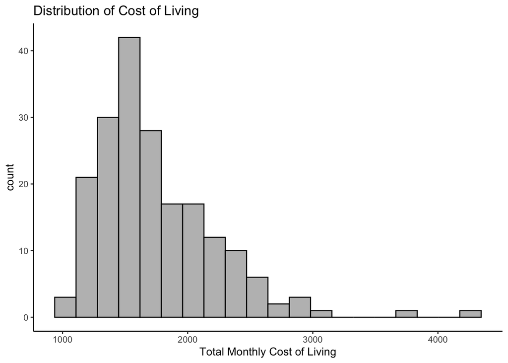

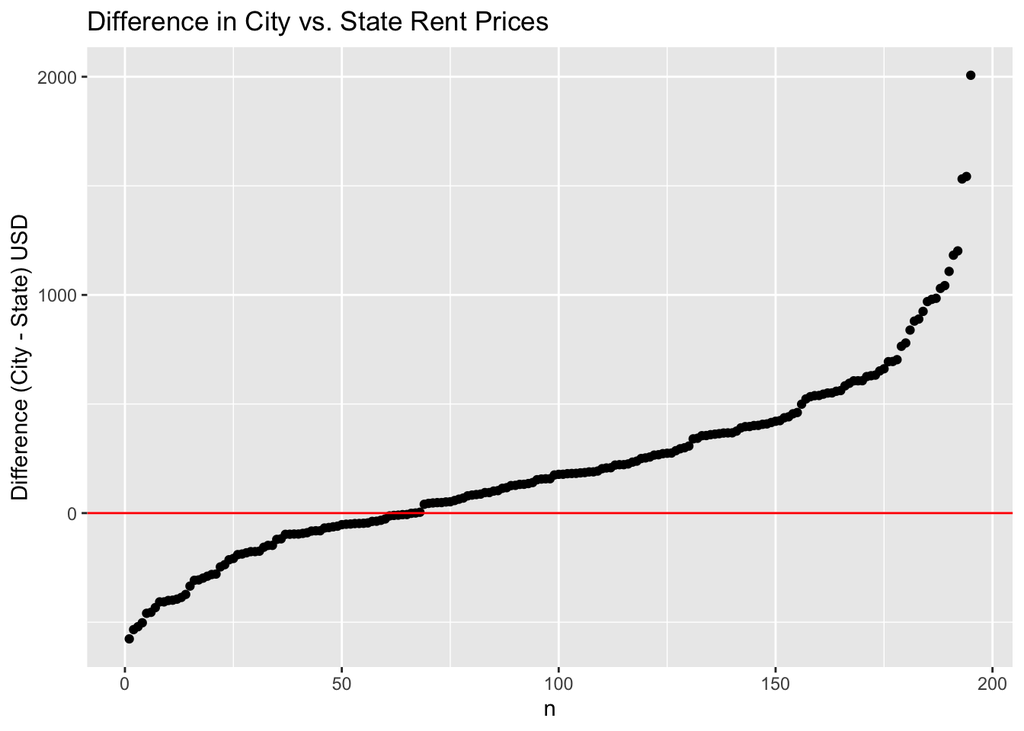

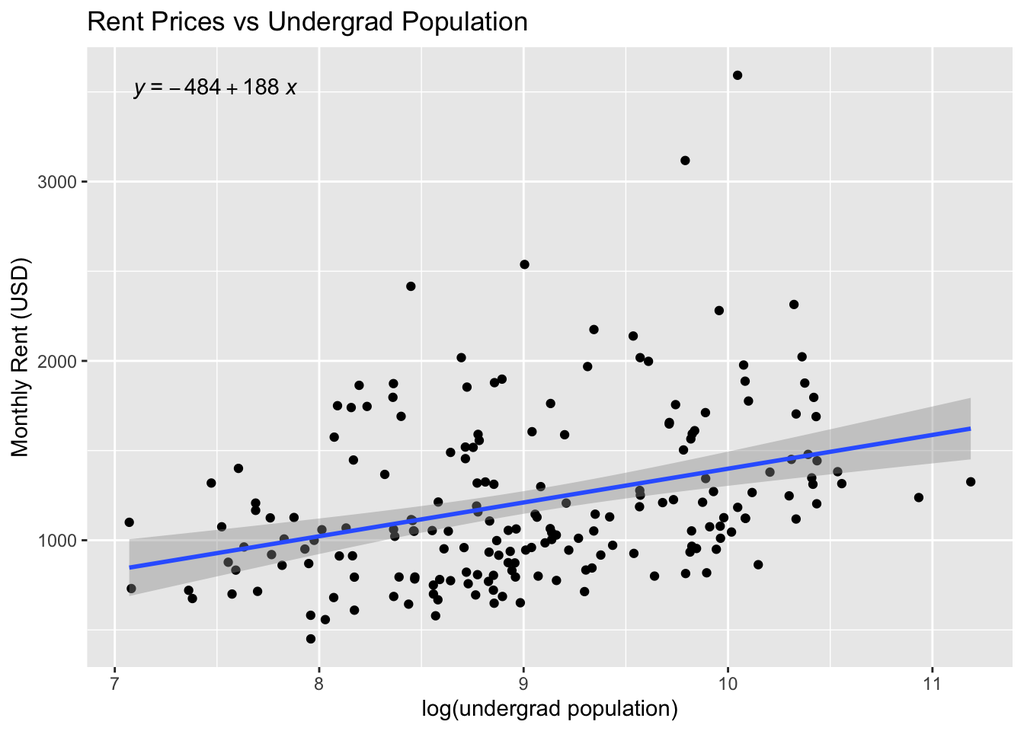